# Uncertainty of spatial averages and totals

A Python implementation of Wadoux & Heuvelink (2023): parity with the authors’ R script, verification on synthetic truth, and ablations

Published

October 13, 2026

# Summary

This report documents `pyspatialuncertainty`, a Python implementation of the Monte Carlo method of [Wadoux & Heuvelink (2023)](https://doi.org/10.1111/2041-210X.14106). The method estimates the uncertainty of spatial averages and totals of maps. The report also covers a per-class extension for maps of calibrated class probabilities. Its main findings:

**Parity with the authors’ R script.**

- The R script was run unchanged apart from two RStudio-only lines, and its intermediates were exported.
- On those inputs, the Python standardized errors, sample variogram and correlogram all match R. So does the integrand on the script’s own 1,000 Monte Carlo pairs, to within 4e-16.
- Python’s Monte Carlo estimate of the block variance with m = 10⁶ pairs is 0.09824 ± 0.00009. R gives 0.09808 ± 0.00009 with m = 10⁶ and 0.09798 with the script’s m = 1,000. The differences are 1.2 and 0.1 combined Monte Carlo standard errors.

**Verification on synthetic truth (continuous maps).**

- The scenario has known non-stationary σ and known correlated errors. With the true σ and correlation, the Monte Carlo estimate matches the exact block SD (median ratio 1.000 for 8 × 8-cell blocks).
- In that oracle case, 90 % intervals cover the truth 90 % of the time for 8 × 8 blocks.
- With a correlogram *fitted* to 300 validation errors, coverage is 90 % for 8 × 8 blocks and 84 % for the whole domain. For large blocks, errors in the long-range part of the fitted correlogram dominate.

**The two naive alternatives fail as the paper warns.**

- Averaging point SDs overstates the block SD by up to 7.5 times, at the domain scale.
- Assuming independent errors understates it by a factor of up to 16, and 90 % intervals then cover only 8 %.

**The method carries any error in σ straight into the result.** The correlogram is normalised by its sill, so the method trusts σ for scale. Scaling σ by c scales the block SD by c. Coverage falls to 59 % for c = 0.5 and rises to 100 % for c = 2. The fitted sill of the standardized errors (≈ 1/c²) is the diagnostic. In the authors’ example it is 0.65.

The **categorical** and **pipeline** results are in Section 3.2 and Section 3.3.

# 1 Methods

## 1.1 The method of Wadoux & Heuvelink (2023)

Let ε(s) be the point-support prediction error of a map. For a block *B* (Eq. 7 of the paper),

$$\operatorname{var}\Big(\frac{1}{|B|}\int_B \varepsilon(s)\,ds\Big)
= \frac{1}{|B|^2}\int_B\int_B \sigma(s)\,\sigma(u)\,\rho(|s-u|)\,ds\,du .$$

The two ingredients are:

- **σ(s)**, the point-support prediction-error SD. It comes from the predictive distribution of any mapping model, e.g. a quantile regression forest (QRF).
- **ρ(h)**, the correlation function of the *standardized* errors ε/σ. It comes from a variogram fitted to standardized cross-validation errors, using ρ(h) = (sill − γ(h))/sill.

The double integral equals E[σ(S)σ(U)ρ(|S − U|)] for independent uniform points S, U in *B*. It is estimated by averaging over *m* pairs, with m = 10,000 in the paper and 1,000 in the R script. The variance of the block total is |B|² times that of the block average, and normal prediction intervals follow from the central limit theorem.

## 1.2 Categorical extension

For class *k* with calibrated probability $p_k$ and indicator $I_k$, the procedure is the same as above:

1. **Error and SD.** The error is $e_k = I_k - p_k$, with $\sigma_k = \sqrt{p_k(1-p_k)}$.
2. **Correlogram.** One correlogram is fitted per class to the standardized errors $e_k/\sigma_k$ at validation points.
3. **Integral.** The integral is evaluated as above, with all classes sharing the same point pairs.
4. **Predictions.** The expected fraction is the block mean of $p_k$, and the expected area is $|B|$ times that. Intervals are clipped to [0, 1].

Probabilities that do not sum to one, or that are exactly 0 or 1, are rejected. Only marginal per-class uncertainty is modelled.

## 1.3 Implementation

[output not shown]

## 1.4 Verification design

**Parity with R.** The authors’ script ([`AlexandreWadoux/UncertaintySpatialAggregation@934481f`](https://github.com/AlexandreWadoux/UncertaintySpatialAggregation)) ran under R 4.3.3 with gstat 2.1-1, ranger 0.16.0, raster 3.6-26 and spatstat 3.0-7. A harness re-drew the script’s Monte Carlo pairs from the saved RNG state and asserted bit-identical results. Python consumed the exported intermediates, because R’s random streams and ranger cannot be reproduced exactly in Python.

**Synthetic truth.** The method targets the *continuous* block average. The synthetic fields are therefore simulated on a sub-grid with 4 × 4 nodes per map cell, and the true block value is the sub-grid mean. Point-scale nugget variation enters only the point observations, which are the validation data. Fields are drawn exactly by FFT circulant embedding.

| Scenario | Truth | What the method receives |
| --- | --- | --- |
| Continuous errors (`ErrorModelScenario`) | 128 × 128 cells. Errors σ(s)·ε*(s), with σ ∈ [0.5, 2] non-stationary and ε* = nugget + exponential(range *a*). Baseline: *a* = 8 cells, nugget 0.25. | c·σ, and 300 validation errors |
| Class maps (`LatentClassScenario`) | A latent μ(s) + η(s) thresholded into 3 classes (≈ 60/30/10 %). η = nugget + exponential noise. Signal-to-noise Var(μ)/Var(η). | Exactly calibrated p (optionally temperature-scaled), and 300 validation labels |
| Full pipeline (`PipelineScenario`) | The R script’s design: trend + GRF 5·exp(−h/25) on [0, 100]², 200 samples. | Ranger-style QRF predictions and σ, and 10-fold CV errors |

**Estimators.** The same four are compared throughout:

- `method`: the paper’s procedure with a fitted correlogram;
- `oracle`: the true σ and correlation; for class maps, the exact domain-averaged correlogram of the standardized indicator errors;
- `naive_avg`: the mean of σ over the block;
- `naive_indep`: √Σσ²/n.

**Metrics.** For each configuration, 500 realizations (baseline) or 300 (ablations) were run. The metrics are:

- **coverage** of 50/80/90/95 % normal intervals, with 95 % CIs from a cluster bootstrap over realizations;
- **SD ratio**, the RMS of the estimated SD over realizations divided by the true SD. The true SD is the brute-force RMS of the block errors, and is also checked against the exact value where one is available.

# 2 Parity with the authors’ R script

Table 1: Python against R on the R script’s own exported inputs.

| quantity | result |
| --- | --- |
| standardized CV errors (step 3) | max abs. diff = 0.0e+00 |
| sample variogram γ, gstat defaults (step 4) | max rel. diff = 1.1e-15 (same pair counts) |
| correlogram of the nested model (step 4) | max abs. diff = 0.0e+00 |
| integrand on the script’s 1,000 MC pairs (step 6) | max abs. diff = 4.4e-16 |
| block variance: R script, m = 1,000 | 0.09798 ± 0.00258 |
| block variance: R, m = 10⁶ | 0.09808 ± 0.00009 |
| block variance: Python, m = 10⁶ | 0.09824 ± 0.00009 |

The R script’s results for the whole domain:

- block mean prediction 12.913;
- block SD 0.3130;
- 90 % interval [12.400, 13.426], which contains the true mean 12.906.

The same function in Python, given the same inputs, reproduces these within Monte Carlo error. The test suite also checks gstat’s fitted parameters for `fit.method` 1, 6 and 7 (agreement to about 10⁻⁴) and gstat’s `variogramLine` for every supported model.

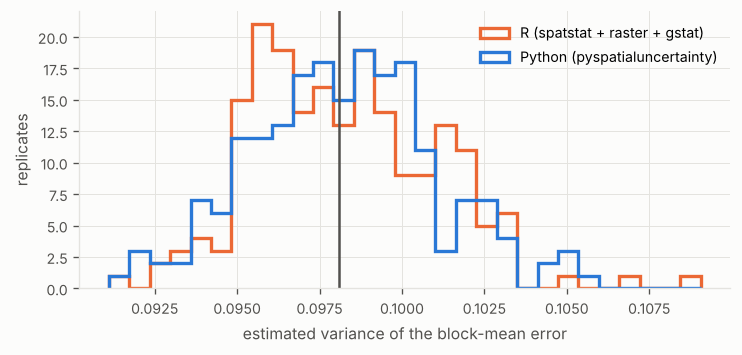

Figure 1: Sampling distribution of the R script’s Monte Carlo estimator (m = 1,000), from 200 replicates in R and 200 in Python on the same inputs. The vertical line is the m = 10⁶ estimate.

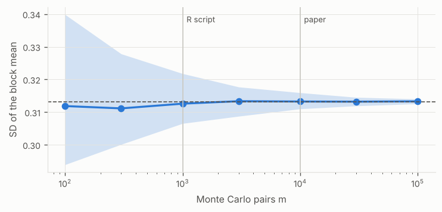

Figure 2: Monte Carlo convergence on the R example (200 replicates per m). The band spans the 5th to 95th percentile of the estimated block SD; the dashed line is the m = 10⁶ value.

The spread of the Monte Carlo estimate shrinks as $1/\sqrt{m}$. Half the 90 % range of the estimated SD is 2.4 % of its value at the script’s m = 1,000, and 0.8 % at the paper’s m = 10,000. The package reports the Monte Carlo standard error with every estimate, so users can choose m deliberately.

# 3 Verification on synthetic truth

## 3.1 Continuous maps

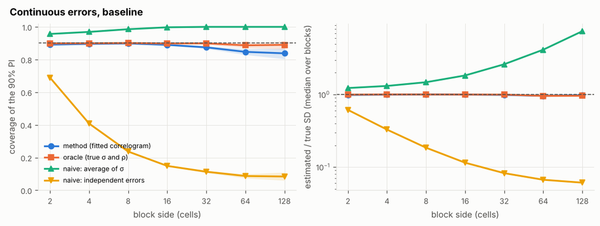

Figure 3: Continuous baseline (500 realizations). Left: coverage of 90 % intervals by block size, with cluster-bootstrap 95 % bands. Right: estimated over true SD.

Table 2: Continuous baseline: coverage at four nominal levels, pooled over block sizes, plus the RMS of the z-scores (1 if the SDs are right).

| estimator | 50 % | 80 % | 90 % | 95 % | z RMS (median over groups) |
| --- | --- | --- | --- | --- | --- |
| method | 0.478 | 0.768 | 0.874 | 0.929 | 1.056 |
| naive_avg | 0.823 | 0.964 | 0.989 | 0.996 | 0.466 |
| naive_indep | 0.101 | 0.187 | 0.233 | 0.270 | 10.441 |
| oracle | 0.494 | 0.793 | 0.896 | 0.947 | 1.004 |

**Oracle.** With the true σ and correlation, the Monte Carlo estimate agrees with the exact block SD, computed by FFT on the sub-grid, at every block size. The coverage of every interval level matches its nominal value. So the integration, the block geometry and the definition of the truth are mutually consistent.

**Fitted correlogram.** The method is close to nominal for blocks up to about 16 × 16 cells. Coverage falls for the largest blocks, to 84 % for the whole domain, even though the median SD ratio stays near 1 (0.98). The cause is variability, not bias. The domain-scale variance depends on the long-range part of the correlogram, which 300 validation points pin down poorly. In some realizations the SD is much too small, and those intervals miss.

## 3.2 Class probability maps

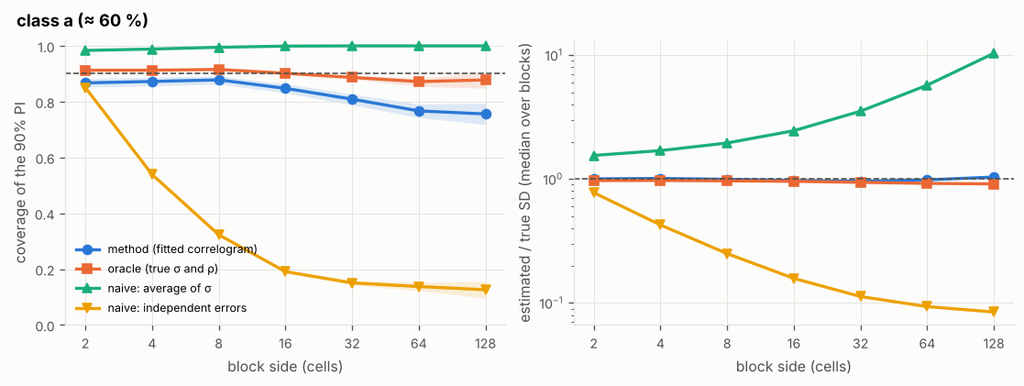

(a) Categorical baseline (500 realizations), one row per class: coverage of 90 % intervals and SD ratio by block size.

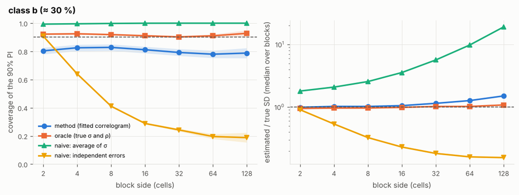

(b)

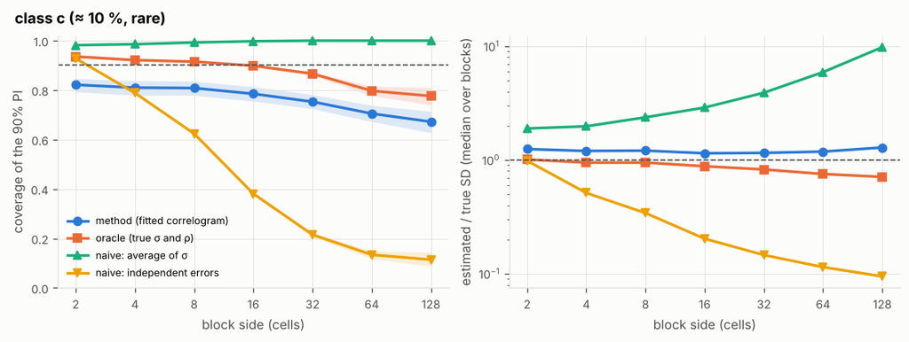

(c)

Figure 4

For 8 × 8-cell blocks, the fitted method’s 90 % intervals have this coverage:

|  | class a (≈ 60 %) | class b (≈ 30 %) | class c (≈ 10 %, rare) |
| --- | --- | --- | --- |
| method coverage | 88 % | 83 % | 81 % |
| method SD ratio | 1.00 | 1.02 | 1.21 |
| oracle coverage | 92 % | 92 % | 92 % |

The oracle uses the exact domain-averaged correlogram. Comparing it with the truth shows how much is lost by assuming a *stationary* correlation of the standardized indicator errors. For a thresholded latent field, that correlation really depends on the probabilities at both locations. Comparing the method with the oracle shows the additional cost of estimating one correlogram per class from 300 binary observations. For the rare class, few validation points carry a positive indicator, so its correlogram is the hardest to estimate. For the whole domain, even the oracle covers only 78 % for the rare class, and 88 % for class a. There the stationary approximation itself is the limiting factor.

## 3.3 The R example as a full pipeline

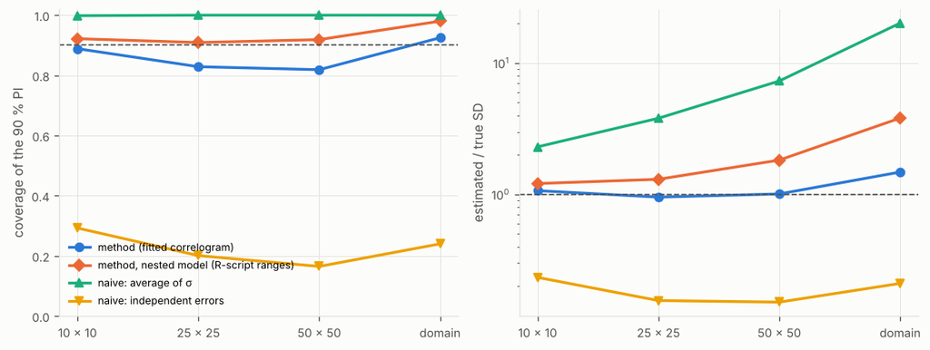

Figure 5: The R script’s design re-run 200 times (new field, sample and ranger-style QRF each time). Coverage of 90 % intervals (left) and SD ratio (right) for the whole domain and for tiles of 10, 25 and 50 nodes.

In the Python port, the median variance of the standardized CV errors is 0.54. For the authors’ own realization it is 0.63, and their hand-set variogram sill is 0.65. Ranger’s quantile regression forest makes σ too wide by a factor of about 1/√0.6 ≈ 1.3. The faithful method normalises the variogram, so it carries this over-dispersion into the block SDs.

Correlogram fitting interacts with this. For tiles, the automatic single-structure fit decays faster than the true error correlation, which roughly offsets the wide σ: the median SD ratio is 0.95 for 25 × 25-node tiles. But the fitted correlogram varies between realizations, and coverage falls short at 83 %. The R script’s nested model, with its ranges fixed and its sills fitted, keeps the weak long-range structures and so gives larger SDs: a median ratio of 1.30 and coverage of 91 % for the same tiles. For the whole domain, both over-estimate the SD (median ratios 1.5 and 3.8), with coverage of 92 % and 98 %. In short, the over-dispersed QRF σ and the uncertain long-range correlation dominate the accuracy of the end-to-end pipeline.

# 4 Ablations

Each ablation changes one factor relative to the baseline. The panels show the fitted method for four block sizes. The tables give coverage pooled over all tiles for every estimator, including the naive baselines.

## 4.1 Continuous maps

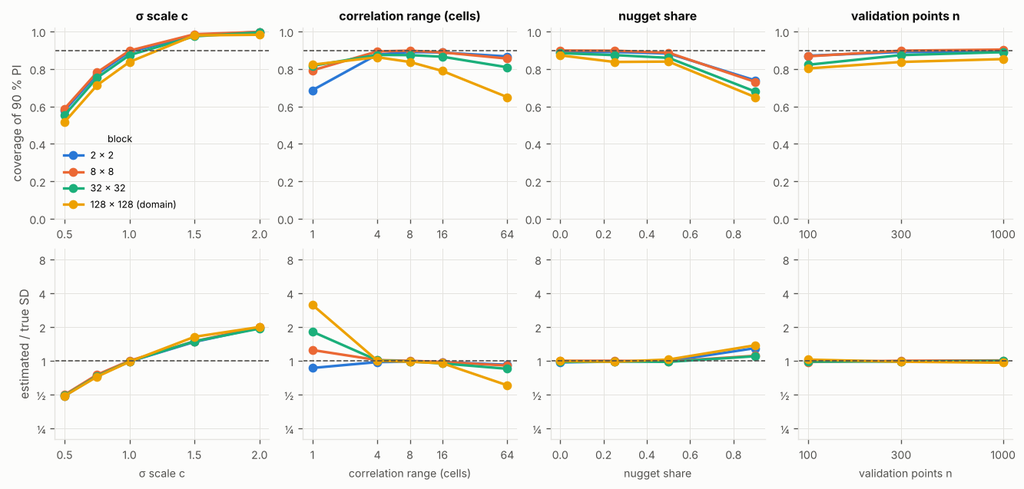

Figure 6: Continuous ablations (fitted method). Top: coverage of 90 % intervals; bottom: estimated over true SD. σ scale = σ handed to the method divided by the true σ; range = exponential range parameter in cells; nugget = share of the standardized-error variance; n = number of validation points.

Table 3: Misspecified σ (continuous): coverage of 90 % intervals pooled over tiles. ‘constant’ passes a constant σ (the domain mean) instead of the true non-stationary σ.

| σ handed to the method | method | oracle | naive_avg | naive_indep |
| --- | --- | --- | --- | --- |
| 0.5 | 0.560 | 0.896 | 0.860 | 0.133 |
| 0.75 | 0.759 | 0.896 | 0.953 | 0.195 |
| 1.0 (baseline) | 0.876 | 0.896 | 0.987 | 0.252 |
| 1.5 | 0.980 | 0.905 | 0.999 | 0.354 |
| 2.0 | 0.995 | 0.902 | 1.000 | 0.430 |
| constant | 0.856 | 0.901 | 0.978 | 0.264 |

Table 4: Correlation range and nugget (continuous): coverage of 90 % intervals pooled over tiles.

| factor | level | method | oracle | naive_avg | naive_indep |
| --- | --- | --- | --- | --- | --- |
| range | 1.0 | 0.786 | 0.903 | 1.000 | 0.645 |
| range | 4.0 | 0.878 | 0.903 | 0.993 | 0.311 |
| range | 8.0 (baseline) | 0.876 | 0.896 | 0.987 | 0.252 |
| range | 16.0 | 0.863 | 0.900 | 0.979 | 0.223 |
| range | 64.0 | 0.803 | 0.899 | 0.964 | 0.208 |
| nugget | 0.0 | 0.887 | 0.903 | 0.974 | 0.223 |
| nugget | 0.25 (baseline) | 0.876 | 0.896 | 0.987 | 0.252 |
| nugget | 0.5 | 0.869 | 0.903 | 0.996 | 0.292 |
| nugget | 0.9 | 0.702 | 0.898 | 1.000 | 0.521 |

**Misspecified σ.** The block SD scales with the σ that the method receives, and coverage follows. The fitted sill of the standardized errors reveals the problem: its median is 3.99 when σ is halved and 0.25 when σ is doubled, against 1 when calibrated. Passing a constant σ in place of the true non-stationary one has a milder effect.

**Correlation range.**

- **Very short ranges (1 cell).** The first lag class of the default sample variogram (cutoff/15 ≈ 4 cells) is too coarse to resolve them. The fitted correlogram is wrong in both directions: too low for the smallest blocks and too high for the largest.
- **Very long ranges (64 cells, practical range 192 on a 128-cell domain).** The sample variogram never reaches its sill within the cutoff. The sill-normalised correlogram then underestimates the correlation, and large blocks are under-covered.

**Nugget.** With a nugget share of 0.9, 16 % of the fits are pure nugget. The paper’s continuous integral is then exactly zero, and coverage collapses for those realizations. This is a property of the faithful method: a pure-nugget correlogram implies that the errors average out completely.

**Number of validation points.** More validation points give better correlograms, and coverage moves towards nominal.

## 4.2 Class probability maps

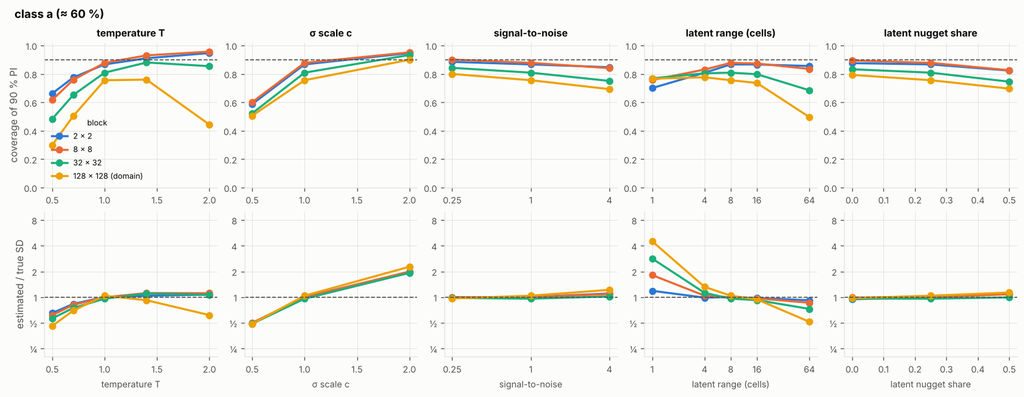

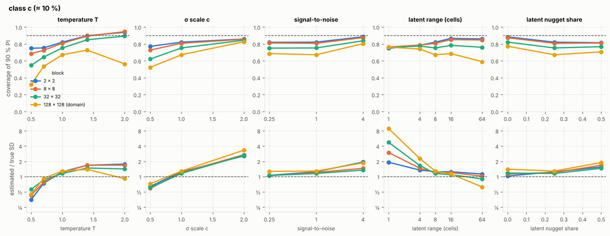

(b)

Figure 7

Table 5: Miscalibration by temperature scaling: coverage of 90 % intervals pooled over tiles, and the median bias of the expected class fraction relative to the RMS error (8 × 8 blocks).

| class | temperature | method | oracle | naive_avg | naive_indep | bias / RMSE |
| --- | --- | --- | --- | --- | --- | --- |
| a | 1.0 (baseline) | 0.83 | 0.90 | 1.00 | 0.33 | 0.00 |
| a | 0.5 | 0.53 | 0.81 | 0.95 | 0.28 | -0.39 |
| a | 0.7 | 0.68 | 0.85 | 0.98 | 0.32 | -0.27 |
| a | 1.4 | 0.88 | 0.86 | 1.00 | 0.29 | 0.27 |
| a | 2.0 | 0.83 | 0.68 | 1.00 | 0.25 | 0.51 |
| b | 1.0 (baseline) | 0.80 | 0.92 | 1.00 | 0.41 | -0.00 |
| b | 0.5 | 0.60 | 0.85 | 0.97 | 0.36 | 0.35 |
| b | 0.7 | 0.70 | 0.89 | 0.99 | 0.40 | 0.25 |
| b | 1.4 | 0.88 | 0.89 | 1.00 | 0.39 | -0.19 |
| b | 2.0 | 0.89 | 0.77 | 1.00 | 0.34 | -0.32 |
| c | 1.0 (baseline) | 0.76 | 0.87 | 0.99 | 0.45 | -0.00 |
| c | 0.5 | 0.59 | 0.80 | 0.95 | 0.41 | 0.33 |
| c | 0.7 | 0.67 | 0.84 | 0.98 | 0.46 | 0.24 |
| c | 1.4 | 0.85 | 0.82 | 1.00 | 0.41 | -0.38 |
| c | 2.0 | 0.86 | 0.54 | 1.00 | 0.33 | -0.71 |

**Signal-to-noise, range and nugget.** Higher signal-to-noise gives sharper probabilities, so smaller σ_k and fewer validation points near the class boundaries. The latent range and nugget act much as in the continuous case, except that the indicator transform makes the effective correlation shorter and weaker than the latent correlation.

## 4.3 The R-example pipeline

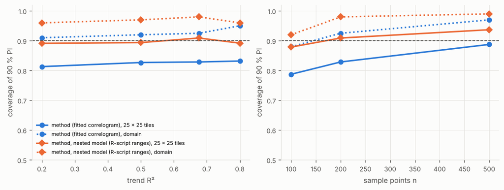

Figure 8: Pipeline ablations: share of variance explained by the trend (R² of the trend; the R script has 0.68) and number of sample points.

# 5 Discussion and limitations

- **Implementation.** The core computation is right. Given the same inputs, the package reproduces the authors’ R script exactly where the computation is deterministic and within Monte Carlo error where it is stochastic. With the true σ and correlation it recovers exact block variances at every scale.
- **Where the uncertainty comes from.** The method’s accuracy in practice depends almost entirely on its inputs: the calibration of σ and the quality of the fitted correlogram.
  - The sill normalisation in step 4 discards the one statistic that would reveal a mis-scaled σ. Reporting the fitted sill alongside the block SDs is cheap and should be routine.
  - For large blocks, the weak long-range part of the correlogram dominates, and it is the part a sample variogram estimates worst. Analyst judgement, such as the nested model in the R script, matters.
- **Nugget and support.** The estimator targets continuous block averages, so a nugget contributes nothing. That is right for micro-scale variation and measurement error. It is not right if the quantity of interest is the mean of a finite set of point values. The synthetic truth used here is consistent with the paper’s estimand.
- **Categorical mode.**
  - It keeps the continuous machinery but relies on a stationary correlogram of standardized indicator errors. That is an approximation, and its quality depends on class prevalence and the sharpness of the probabilities.
  - Only marginal per-class uncertainty is provided.
  - Probabilities must be calibrated. Temperature-scaled (miscalibrated) probabilities distort both the expected areas and their uncertainty.
- **Scope.** Not covered: geographic coordinates, which need reprojecting; bounded or skewed intervals; and cross-class dependence.

Software: pyspatialuncertainty 1.0.0, numpy 2.5.4, scipy 1.18.1, xarray 2026.9.0, rioxarray 0.23.0, polars 2.0.0, shapely 2.2.0, scikit-learn 1.9.1. Reference R run: R version 4.3.3 (2024-02-29).